# Practical Machine Learning - Final Project

Human Activity Recognition

Maria Luiza Mondelli

2019-08-19

## Introduction

This project is based on data from accelerometers on the belt, forearm, arm, and dumbell of 6 participants that were asked to perform barbell lifts correctly and incorrectly in 5 different ways (or classes) as follows:

1. Exactly according to the specification
2. Throwing the elbows to the front
3. Lifting the dumbbell only halfway
4. Lowering the dumbbell only halfway
5. Throwing the hips to the front

The goal of this project is to predict the manner in which the participants did the exercise.

## First things first: getting the data

We will first download the training and testing datasets:

```r
data_dir = "./data"
training_url = "https://d396qusza40orc.cloudfront.net/predmachlearn/pml-training.csv"
test_url = "https://d396qusza40orc.cloudfront.net/predmachlearn/pml-testing.csv"

if (!file.exists(data_dir)) {
  dir.create(data_dir)
}
if (!file.exists(file.path(data_dir, 'training.csv'))) {
  download.file(training_url, destfile=file.path(data_dir, 'training.csv'))
}
if (!file.exists(file.path(data_dir, 'test.csv'))) {
  download.file(test_url, destfile=file.path(data_dir, 'test.csv'))
}

training <- read.csv(file.path(data_dir, 'training.csv'))
testing <- read.csv(file.path(data_dir, 'test.csv'))
```

## Preprocessing

Then, we can have a look of what the data contains:

```r
dim(training); dim(testing)
```

```
## [1] 19622   160
```

```
## [1]  20 160
```

```r
colnames(training)
```

```
##   [1] "X"                        "user_name"
##   [3] "raw_timestamp_part_1"     "raw_timestamp_part_2"
##   [5] "cvtd_timestamp"           "new_window"
##   [7] "num_window"               "roll_belt"
##   [9] "pitch_belt"               "yaw_belt"
##  [11] "total_accel_belt"         "kurtosis_roll_belt"
##  [13] "kurtosis_picth_belt"      "kurtosis_yaw_belt"
##  [15] "skewness_roll_belt"       "skewness_roll_belt.1"
##  [17] "skewness_yaw_belt"        "max_roll_belt"
##  [19] "max_picth_belt"           "max_yaw_belt"
##  [21] "min_roll_belt"            "min_pitch_belt"
##  [23] "min_yaw_belt"             "amplitude_roll_belt"
##  [25] "amplitude_pitch_belt"     "amplitude_yaw_belt"
##  [27] "var_total_accel_belt"     "avg_roll_belt"
##  [29] "stddev_roll_belt"         "var_roll_belt"
```

[output cut: 65 more lines]

```r
#summary(training)
```

Some variables contain NA values and zero-length strings. Then, we need to perform a data cleaning step in order to prepare the data that will be consumed by the ML algorithms (for both test and training datasets). First, we can replace zero-length strings with NA values. After that, we can remove the variables that contain NA values, reducing the dimensionality of our data.

```r
# Replace zero-length strings
training[training == "" ] <- NA
testing[testing == "" ] <- NA
# Remove variables with NA values
training <- training[, colSums(is.na(training)) == 0]
testing <- testing[, colSums(is.na(testing)) == 0]
# Check dimensions
dim(training); dim(testing)
```

```
## [1] 19622    60
```

```
## [1] 20 60
```

Also, we can remove the first 7 variables, since they are related to the project setting (participant name, timestamps, etc) and do not seem to impact the outcome:

```r
training <- training[,-c(1:7)]
variables <- colnames(training)[-53] # Remove the classe variable
testing <- testing[, variables]
```

To identify if other features need to be removed from the dataset, we can use the *nearZeroVar* function that basically will look for features without variability.

```r
zeroVar <- nearZeroVar(training, saveMetrics=TRUE); zeroVar
```

```
##                      freqRatio percentUnique zeroVar   nzv
## roll_belt             1.101904     6.7781062   FALSE FALSE
## pitch_belt            1.036082     9.3772296   FALSE FALSE
## yaw_belt              1.058480     9.9734991   FALSE FALSE
## total_accel_belt      1.063160     0.1477933   FALSE FALSE
## gyros_belt_x          1.058651     0.7134849   FALSE FALSE
## gyros_belt_y          1.144000     0.3516461   FALSE FALSE
## gyros_belt_z          1.066214     0.8612782   FALSE FALSE
## accel_belt_x          1.055412     0.8357966   FALSE FALSE
## accel_belt_y          1.113725     0.7287738   FALSE FALSE
## accel_belt_z          1.078767     1.5237998   FALSE FALSE
## magnet_belt_x         1.090141     1.6664968   FALSE FALSE
## magnet_belt_y         1.099688     1.5187035   FALSE FALSE
## magnet_belt_z         1.006369     2.3290184   FALSE FALSE
## roll_arm             52.338462    13.5256345   FALSE FALSE
## pitch_arm            87.256410    15.7323412   FALSE FALSE
## yaw_arm              33.029126    14.6570176   FALSE FALSE
## total_accel_arm       1.024526     0.3363572   FALSE FALSE
## gyros_arm_x           1.015504     3.2769341   FALSE FALSE
## gyros_arm_y           1.454369     1.9162165   FALSE FALSE
## gyros_arm_z           1.110687     1.2638875   FALSE FALSE
## accel_arm_x           1.017341     3.9598410   FALSE FALSE
## accel_arm_y           1.140187     2.7367241   FALSE FALSE
## accel_arm_z           1.128000     4.0362858   FALSE FALSE
## magnet_arm_x          1.000000     6.8239731   FALSE FALSE
## magnet_arm_y          1.056818     4.4439914   FALSE FALSE
## magnet_arm_z          1.036364     6.4468454   FALSE FALSE
## roll_dumbbell         1.022388    84.2065029   FALSE FALSE
## pitch_dumbbell        2.277372    81.7449801   FALSE FALSE
## yaw_dumbbell          1.132231    83.4828254   FALSE FALSE
## total_accel_dumbbell  1.072634     0.2191418   FALSE FALSE
## gyros_dumbbell_x      1.003268     1.2282132   FALSE FALSE
## gyros_dumbbell_y      1.264957     1.4167771   FALSE FALSE
## gyros_dumbbell_z      1.060100     1.0498420   FALSE FALSE
## accel_dumbbell_x      1.018018     2.1659362   FALSE FALSE
## accel_dumbbell_y      1.053061     2.3748853   FALSE FALSE
## accel_dumbbell_z      1.133333     2.0894914   FALSE FALSE
## magnet_dumbbell_x     1.098266     5.7486495   FALSE FALSE
## magnet_dumbbell_y     1.197740     4.3012945   FALSE FALSE
## magnet_dumbbell_z     1.020833     3.4451126   FALSE FALSE
## roll_forearm         11.589286    11.0895933   FALSE FALSE
## pitch_forearm        65.983051    14.8557741   FALSE FALSE
## yaw_forearm          15.322835    10.1467740   FALSE FALSE
## total_accel_forearm   1.128928     0.3567424   FALSE FALSE
## gyros_forearm_x       1.059273     1.5187035   FALSE FALSE
## gyros_forearm_y       1.036554     3.7763735   FALSE FALSE
## gyros_forearm_z       1.122917     1.5645704   FALSE FALSE
## accel_forearm_x       1.126437     4.0464784   FALSE FALSE
## accel_forearm_y       1.059406     5.1116094   FALSE FALSE
## accel_forearm_z       1.006250     2.9558659   FALSE FALSE
## magnet_forearm_x      1.012346     7.7667924   FALSE FALSE
## magnet_forearm_y      1.246914     9.5403119   FALSE FALSE
## magnet_forearm_z      1.000000     8.5771073   FALSE FALSE
## classe                1.469581     0.0254816   FALSE FALSE
```

Since all selected features so far do have enough variance, we can keep all of them.

## Modeling

Before training the models, we will perform some configuration:

```r
clusters <- makeCluster(detectCores() - 2)
registerDoParallel(clusters, cores = detectCores() - 2)
train.ctrl <- trainControl(method = "cv",
                        number = 4,
                        allowParallel = TRUE,
                        verboseIter = TRUE)
```

We can also split the training dataset, so we wiil be able to check the accuracy of the models later:

```r
inTrain <- createDataPartition(y = training$classe,
                               p = 0.7,
                               list = F)
train <- training[inTrain, ]; test <- training[-inTrain, ]
```

Then, we will use the Random Forest and Stochastic Gradient Boosting methods to perform the predictions.

### Random Forest

```r
model.rf <- train(classe ~ .,
                  data = train,
                  method = "rf",
                  trControl = train.ctrl)
#pred.rf <- predict(model.rf, test)
```

### Stochastic Gradient Boosting

```r
model.gbm <- train(classe ~ .,
                   data = train,
                   method = "gbm",
                   trControl = train.ctrl)
#pred.gbm <- predict(model.gbm, test)
```

Saving the models:

```r
saveRDS(model.rf, paste0(data_dir, "/model_rf.rds"))
saveRDS(model.gbm, paste0(data_dir, "/model_gbm.rds"))
```

### Checking accuracy

```r
model.rf <- readRDS(paste0(data_dir, "/model_rf.rds"))
model.gbm <- readRDS(paste0(data_dir, "/model_gbm.rds"))
pred.rf <- predict(model.rf, test)
pred.gbm <- predict(model.gbm, test)
```

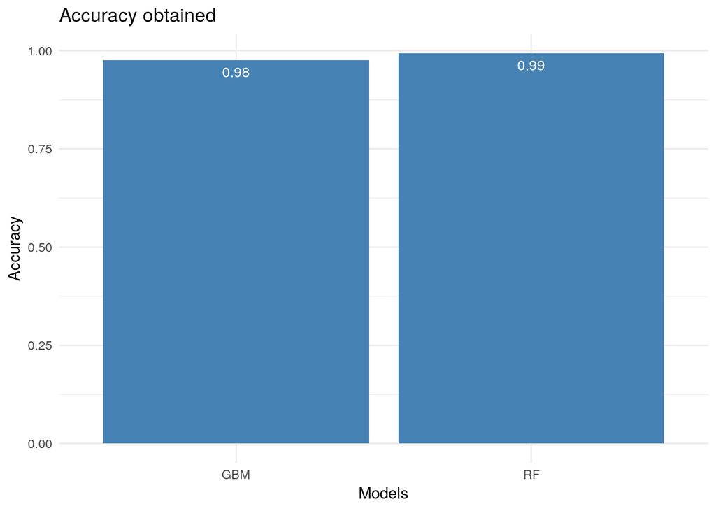

```r
accuracy.rf <- confusionMatrix(pred.rf, test$classe)$overall['Accuracy']
accuracy.gbm <- confusionMatrix(pred.gbm, test$classe)$overall['Accuracy']
df <- data.frame(models = c('RF', 'GBM'),
                 accuracy = c(accuracy.rf, accuracy.gbm))
ggplot(df, aes(x = models, y = accuracy)) +
  geom_bar(stat="identity", fill="steelblue") +
  geom_text(aes(label=round(accuracy, 2)), vjust=1.6, color="white", size=3.5) +
  labs(x = 'Models', y = 'Accuracy', title = 'Accuracy obtained') +
  theme_minimal()
```

### Predicting with the test dataset

Finally, we will use the downloaded test dataset to predict the ‘classe’ using RF:

```r
pred.test <- predict(model.rf, testing); pred.test
```

```
##  [1] B A B A A E D B A A B C B A E E A B B B
## Levels: A B C D E
```